# Лабораторная работа №6

Имитационное моделирование

Ибрахим Мохсейн Алькамаль

1032225432@rudn.ru

Российский университет дружбы народов

2026-09-04

# Информация

## Докладчик

- Ибрахим Мохсейн Алькамаль
- Российский университет дружбы народов

# Цель работы

- Изучить реализацию эпидемиологической модели SIR с использованием сетей Петри.
- Выполнить детерминированное и стохастическое моделирование.
- Исследовать влияние коэффициента заражения $\beta$.
- Сравнить полученные динамики модели.

# Выполнение лабораторной работы

## Подготовка рабочего проекта

- Создан и активирован проект `lab06/project`.
- Использован скрипт `setup_project.jl`.
- Сформировано проектное окружение Julia.
- Установлены необходимые зависимости.

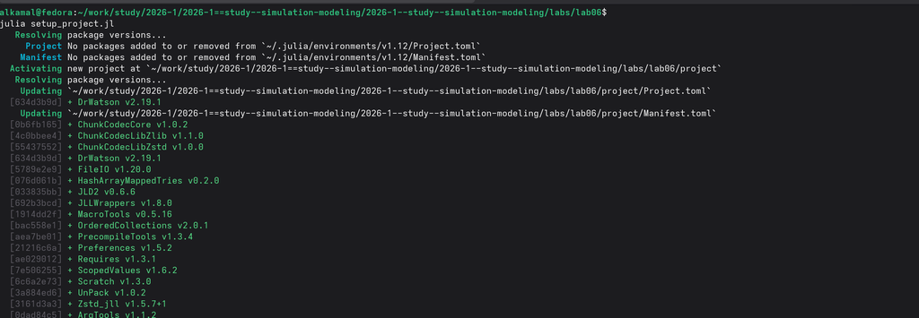

Рисунок 1: Создание рабочего проекта и установка зависимостей Julia

## Проверка проектного окружения

- Проект запущен командой `julia --project=.`.
- Состав окружения проверен с помощью `Pkg.status()`.
- Проверено наличие необходимых пакетов.

[figure not shown]

Рисунок 2: Проверка установленных пакетов проектного окружения Julia

## Базовый прогон модели SIR

- Созданы модуль `SIRPetri.jl` и скрипт `sirpetri_run.jl`.
- Выполнен базовый прогон модели SIR.
- Результаты сохранены в `sir_det.csv` и `sir_stoch.csv`.
- Созданы графики `sir_det_dynamics.png` и `sir_stoch_dynamics.png`.

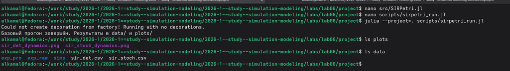

Рисунок 3: Выполнение базового прогона модели SIR и сохранение результатов

## Преобразование базового эксперимента в литературный стиль

- Подготовлен файл `sirpetri_run_literary.jl`.
- Выполнен скрипт `tangle.jl`.
- Сформированы Julia-скрипт, документ Quarto и Jupyter Notebook.

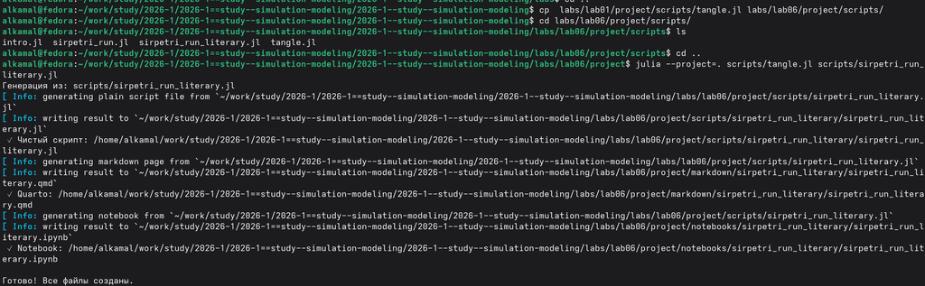

Рисунок 4: Генерация Julia-скрипта, документа Quarto и Jupyter Notebook для модели SIR

## Выполнение базового эксперимента в Jupyter Notebook

- Выполнен `sirpetri_run_literary.ipynb`.
- Получена детерминированная динамика состояний `S`, `I` и `R`.
- Получена стохастическая динамика состояний `S`, `I` и `R`.
- Отображено изменение численности групп во времени.

[figure not shown]

Рисунок 5: Детерминированная и стохастическая динамика модели SIR в Jupyter Notebook

## Сканирование параметра заражения

- Выполнен скрипт `sirpetri_scan_parameters.jl`.
- Исследовано влияние коэффициента заражения $\beta$.
- Результаты сохранены в `data/sir_scan.csv`.
- График сохранён в `plots/sir_scan.png`.

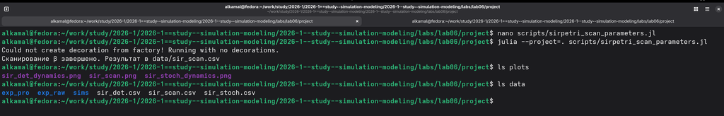

Рисунок 6: Выполнение сканирования коэффициента заражения модели SIR

## Преобразование сканирования параметров в литературный стиль

- Подготовлен файл `sirpetri_scan_parameters_literary.jl`.
- Выполнено преобразование с помощью `tangle.jl`.
- Сформированы Julia-скрипт, документ Quarto и Jupyter Notebook.

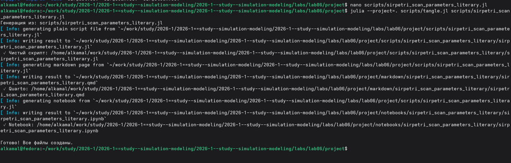

Рисунок 7: Генерация файлов литературной версии сканирования параметров модели SIR

## Анализ результатов сканирования в Jupyter Notebook

- Выполнен `sirpetri_scan_parameters_literary.ipynb`.
- Исследована зависимость `Peak I` от коэффициента $\beta$.
- Исследована зависимость `Final R` от коэффициента $\beta$.
- Результаты сохранены в `data/sir_scan.csv`.

[figure not shown]

Рисунок 8: Зависимость показателей модели SIR от коэффициента заражения β

- Подготовлен и выполнен скрипт `sirpetri_animate.jl`.
- Проверены результаты моделирования.
- Проверено содержимое каталогов `data` и `plots`.

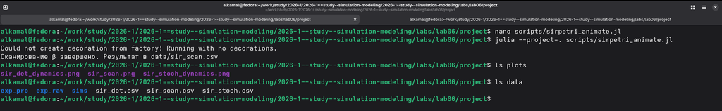

Рисунок 9: Выполнение скрипта визуализации и проверка результатов модели SIR

## Преобразование скрипта визуализации в литературный стиль

- Подготовлен файл `sirpetri_animate_literary.jl`.
- Выполнено преобразование с помощью `tangle.jl`.
- Сформированы Julia-скрипт, документ Quarto и Jupyter Notebook.

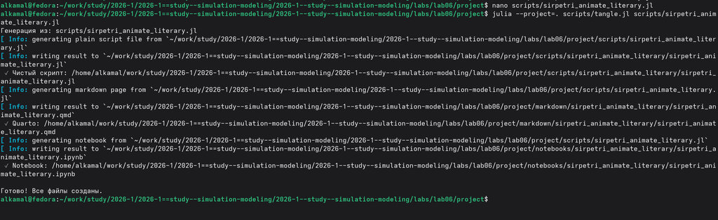

Рисунок 10: Генерация файлов литературной версии визуализации модели SIR

## Выполнение литературной версии в Jupyter Notebook

- Выполнен `sirpetri_animate_literary.ipynb`.
- Получены результаты для $\beta$ от `0.1` до `0.8`.
- Рассчитаны показатели `peak_I` и `final_R`.
- Результаты сохранены в `data/sir_scan.csv`.
- Данные подготовлены для построения графика.

[figure not shown]

Рисунок 11: Таблица результатов и подготовка визуализации параметров модели SIR в Jupyter Notebook

## Формирование итогового отчёта

- Подготовлен и выполнен скрипт `sirpetri_report.jl`.
- Создан график `comparison.png`.
- Создан график `sensitivity.png`.
- Проверены результаты в каталогах `plots` и `data`.

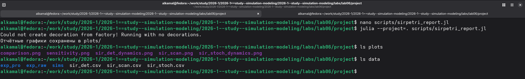

Рисунок 12: Формирование отчётных графиков и проверка результатов моделирования SIR

## Преобразование итогового отчёта в литературный стиль

- Подготовлен файл `sirpetri_report_literary.jl`.
- Выполнено преобразование с помощью `tangle.jl`.
- Сформированы Julia-скрипт, документ Quarto и Jupyter Notebook.

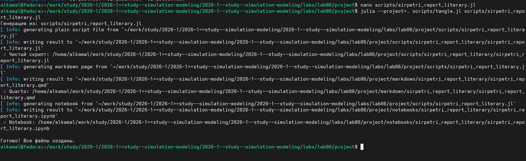

Рисунок 13: Генерация файлов литературной версии итогового отчёта модели SIR

## Анализ результатов в Jupyter Notebook

- Выполнен `sirpetri_report_literary.ipynb`.
- Сравнена детерминированная и стохастическая динамика инфицированных.
- Построена зависимость `Peak I` от коэффициента заражения $\beta$.
- Проведён анализ чувствительности модели.

[figure not shown]

Рисунок 14: Сравнение динамики и анализ чувствительности модели SIR в Jupyter Notebook

# Выводы

- Реализована модель SIR на основе сетей Петри.
- Выполнено детерминированное и стохастическое моделирование.
- Исследовано влияние коэффициента заражения $\beta$.
- Выполнено сравнение детерминированных и стохастических результатов.
- Проведён анализ чувствительности модели.
- Результаты сохранены в CSV-файлах и графиках.
- Литературные версии представлены в форматах Quarto и Jupyter Notebook.